# Pre-reaching infants expect causal agents to reach efficiently

Shari Liu

July 31 2018

# Tables and Figures

**Table 1.** Summary of conditions, design, and sample sizes of Experiments 1-5, and Skerry et al (2013) (SCS) Experiments 1-5, including sample size (N), what motor training procedures were used (effective sticky mittens, ineffective non-sticky mittens, or none), the goal of the person reaching (changing an object’s state, or picking it up), whether the person acted on the object in a spatiotemporally contingent manner (causal: yes, or no), and whether the person wore a mitten (yes or no). Conditions listed under a single experiment (e.g. Exp 1 and 3) included random assignment to condition. For stimuli, see Fig 1. * indicates direct replication. For stimuli, see Fig 1.

| Experiment | N | Training | Goal | Habituation | Causal | Mitten | Stimuli |
| --- | --- | --- | --- | --- | --- | --- | --- |
| 1 | 20 | none | state change | constrained | yes | yes | H1, T1 |
| 1 | 20 | none | state change | unconstrained | yes | yes | H2, T1 |
| 2 | 20 | none | state change | constrained | no | yes | H3, T2 |
| 3* | 26 | none | state change | constrained | yes | yes | H1, T1 |
| 3* | 26 | none | state change | constrained | no | yes | H3, T2 |
| 4 | 20 | none | pick up | constrained | yes | yes | H4, T3 |
| 5 | 20 | none | pick up | constrained | yes | no | H5, T4 |
| SCS 1 | 20 | effective | pick up | constrained | yes | yes |  |
| SCS 2 | 20 | ineffective | pick up | constrained | yes | yes |  |
| SCS 3 | 20 | none | pick up | constrained | yes | yes |  |
| SCS 4* | 26 | effective | pick up | constrained | yes | yes |  |
| SCS 5 | 26 | effective | pick up | unconstrained | yes | yes |  |

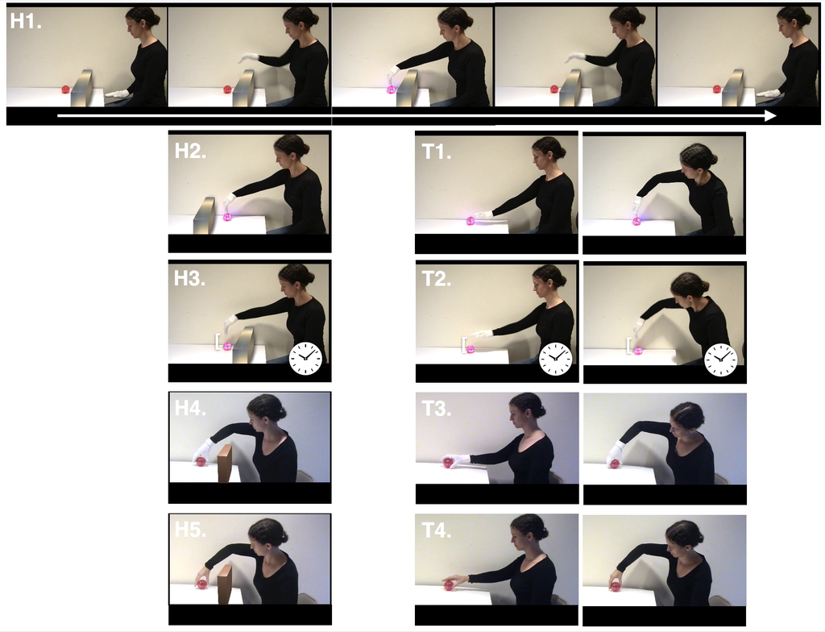

A.

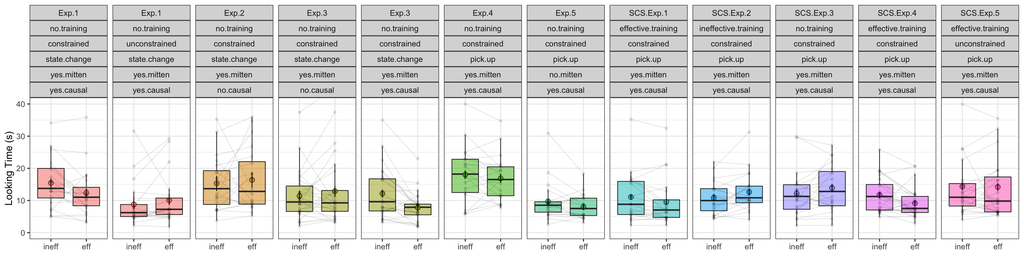

B.

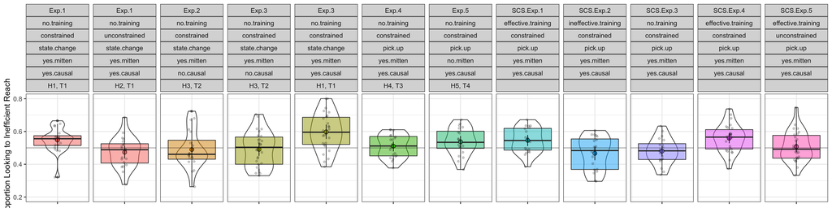

**Figure 2.** Looking time in (A) seconds towards the efficient versus inefficient reach, and (B) proportion looking towards the inefficient reach at test across Experiments 1-5 (n=152) and across Experiments 1-5 in Skerry et al. (2013) (n=112). Labels above each panel list the experiment name (Exp. 1-5, SCS Exp. 1-5), type of motor training (none, ineffective non-sticky mittens, or effective sticky mittens), type of action during habituation (constrained or unconstrained by a barrier), goal (state.change or pick.up), whether her actions appeared to be causal (yes.causal or no.causal), and whether the actress wore a mitten (yes.mitten or no.mitten). Error bars around means indicate within-subjects 95% confidence intervals (A) and bootstrapped 95% confidence intervals (B). Individual points (B) or pairs of points (A) indicate data from a single participant. Horizontal bars within boxes indicate medians, and boxes indicate the middle 2 quartiles of data. Violin plots in (B) indicate distribution of data, area scaled proportionally to the number of observations.

# Results

## Infants’ analysis of causal vs non-causal actions

### Experiment 1

In Experiment 1 (N=40; 20 per condition), we asked whether 3-month-old infants (M=107.675 days, range=91-122, 23 female) expect a person to reach out and cause an object to change state efficiently. We randomly assigned infants were to repeatedly view video clips of a person who reached over a barrier and appeared to cause an object to light up by touching it (H1), or to view the same reaches with the barrier beyond the goal object, out of the person’s way (H2) (a motion that does not appear intentional to infants (Gergely et al., 1995)). Then, infants in both conditions viewed the same pair of alternating test events, in which the barrier was removed and the person reached either efficiently on a novel, direct path or inefficiently on a familiar, indirect path (T1). A mixed effects model, including a fixed interaction between habituation and test event and a random intercept for participant identity, revealed that infants responded differently to the test events across these two habituation conditions, [0.273,0.732], ß=0.781, B(SE)=0.502(0.114), p<.001, two-tailed, 2 participants excluded on the basis of Cook’s Distance. Contrasts from this model revealed that when the person’s reaches were initially constrained by a barrier, infants looked longer at the inefficient action (M=15.448s, SE=0.658) than the efficient action (M=12.368s, SE=0.658) at test, [0.396,1.139], ß=1.194, B(SE)=0.768(0.185), p<.001, one-tailed. Critically, this looking preference cannot be attributed to low-level responses to the curvilinear reach, because infants in the other condition of the experiment, who were randomly assigned to habituate to otherwise identical videos in which the the barrier was behind the object (H2),looked marginally *shorter* at the inefficient (M=8.788s, SE=0.738) and efficient (M=10.104s, SE=0.738) actions, [-0.343,-0.017], ß=-0.28, B(SE)=-0.18(0.081), p=0.016, one-tailed.

### Experiment 2

In Experiment 2 (N=20), pre-registered at https://osf.io/a5byn/, we asked whether infants’ causal analysis of an action is critical to their understanding of this action as intentional, as suggested by past studies of causal perception (Michotte 1963; Muentener and Carey 2010; Leslie 1984). We tested whether infants’ expectations from Experiment 1 depended on their construal of the person as a causal agent (an agent contacting an object, thereby changing its state) or on lower-level scene features (an agent reaching towards an object that happens to illuminate), by manipulating the spatiotemporal continuity of this action. Infants (M=106.7 days, range=93-121, 12 female) were habituated to videos identical to H1, except that the person’s hand stopped 50 pixels above the object (approximately 2 cm on the presentation screen), and the object illuminated after a 0.5 second delay. At test, the person reached efficiently or inefficiently in the absence of the barrier, with the same spatiotemporal gap as in habituation trials (T2). We found that infants looked equally between the inefficient (M=15.306s, SE=1.123) and efficient (M=16.38s, SE=1.123) reach, [-0.191,0.301], ß=0.096, B(SE)=0.055(0.119), p=0.649, two-tailed, mixed effects model with trial type as fixed effect and participants as a random intercept, a result that differed from infants’ responses to the causally effective reaches in Experiment 1 (H1), [-0.623,-0.003], ß=-0.547, B(SE)=-0.313(0.154), p=0.049, two-tailed, mixed effects model with fixed interaction between causality and trial type and participants as a random intercept.

### Experiment 3

Experiment 3 (N=52; 26 per condition), pre-registered at https://osf.io/f2hvd/, attempted to replicate the findings from Experiments 1 and 2 that infants expect causally effective reaches to be efficient, but do not expect efficiency when presented with same actions that are not spatiotemporally continuous. We randomly assigned infants (M=107.154 days, range=92-121, 20 female) to H1 and T1, or H3 and T2: a design that enables us to directly compare infants’ responses to causal vs non-causal actions, using experimenters who are blind to both condition and test event information. Our findings replicated those of the previous two studies: Infants’ tendency to view the agent’s actions as efficiently directed to the goal object again depended on the presentation of actions that elicit an impression of contact causality, in which the agent’s hand contacted the object at the time of the object’s change of state, [-0.815,-0.184], ß=-0.729, B(SE)=-0.5(0.158), p=0.003, two-tailed, mixed effects model with fixed interaction of causality and test event and random intercept for participants. As in Experiment 1, infants looked longer at the inefficient reach (M=12.166s, SE=0.588) than the efficient reach (M=7.791s, SE=0.588) when the person’s actions were causally effective, [0.211,0.66], ß=0.635, B(SE)=0.436(0.112), p<.001, one-tailed, and as in Experiment 2, infants looked equally to the inefficient (M=11.395s, SE=0.818) and efficient (M=12.888s, SE=0.818) reaches when the spatiotemporal gap between her hand the the object’s illumination suggested that she did not cause this event, [-0.289,0.16], ß=-0.094, B(SE)=-0.064(0.112), p=0.284, one-tailed. Together, Experiments 1-3 show that pre-reaching infants apply the principle of efficiency (Gergely & Csibra, 2003) to reaching actions that they themselves have never experienced, and that they only apply this principle to actions that appear to cause changes in the world.

## Infants’ analysis of entrainment actions

### Experiments 4 and 5

Why do infants succeed in these experiments without motor training, yet fail in the experiments of SCS? First, pre-reaching infants may struggle to understand the causal structure of reaching for and retrieving an object without the relevant motor experience. Second, pre-reaching infants may not interpret the reach of a mittened hand, one that looks different from most hands they see, as intentional (Guajardo & Woodward, 2004), causal, and directed to a particular object, without the relevant experience of observing and experiencing their own mittened hands acting causally towards a specific set of objects during training.

To ask whether surface properties of the hand reaching affect infants’ interpretation of the intentionality of these reaches, we ran two additional experiments. In Experiment 4 (N=20), infants (M=107.9 days, range=92-122, 11 female) were habituated to and tested on events where a person reach for and pick up an object identical to those from Experiments 1-3 while wearing the same mitten (H4, T3). In Experiment 5 (N=20), infants (M=107.95 days, range=93-120, 12 female) saw almost identical videos to those from Experiment 4 except that the person reached with a bare hand (H5, T4).

We also compared these results against those from SCS Experiment 3, wherein infants received no mittens training and viewed a person reaching with a mittened hand. The results of Experiment 5 (no mitten) differed from those in SCS Experiment 3 (mitten), [0.047,0.547], ß=0.539, B(SE)=0.297(0.124), p=0.022, two-tailed, mixed effects model with fixed interaction between experiment and test event and random intercept for participants, one influential participant excluded on the basis of Cook’s Distance, whereas the results from Experiment 4 (mitten) only marginally differed from those in SCS Experiment 3 (mitten), [-0.021,0.47], ß=0.43, B(SE)=0.224(0.122), p=0.074, two-tailed, mixed effects model with fixed interaction between experiment and test events and random intercept for participants, 2 influential participants excluded on the basis of Cook’s Distance. This finding accords with reports that young infants trained with mittens view an agent’s reach as goal-directed only if the agent wears the same mittens and interacts with the same objects as they did during training (Gerson & Woodward, 2014; Woodward, 2008). Nevertheless, the differences in infants’ responses to gloved and ungloved hands are not robust in our studies and merit further investigation.

## Results across Experiments 1-5 and SCS

Across Experiments 1-5, we found that pre-reaching infants apply expectations of efficient action to a person who pursues the goal of causing a change in an object while wearing a mitten, but do not apply the same expectation to the same person wearing the same mitten when she picks up the same object. Thus, we suggest that one key difference between the state change events we used in the present experiments, and the pickup events used in SCS and Experiments 4-5, is the causal transparency of these actions: Three-month-old infants do not know how to reach for and grasp objects, and thus may struggle to understand how grasping an object could cause it to rise and move closer to the person reaching for it, thereby fulfilling the goal of the agent to retrieve it. Indeed, infants’ own ability to produce power grasps (the actions tested in Experiment 4 and 5 and in SCS) predicts their ability to represent such grasps as directed towards an object (Bakker et al., 2015). Although the infants in our experiments will not master these grasping actions until around 5 months of age (von Hofsten, 1980), these infants may nevertheless possess the intuition that causal agents behave efficiently, an expectation they apply to events in which an object changes state on contact with an agent’s hand.

To assess the unique effects of our experimental manipulations and those from SCS, we performed an analysis over these two papers (total N=264, 12 conditions). Our analytic approach allows us to assess the independent effects of 5 manipulations (motor training, goal, habituation, causal information, and surface properties of the hand), on infants’ expectations about efficient reaching, while controlling participant variables like age and sex, and also modeling the nested structure of the data (e.g. looks clustered within experiments and within papers). For ease of interpretation, we use average proportion looking to the inefficient action in this analysis, following SCS.

**Table 2.** Regression table for model investigating predictors of sensitivity to action efficiency across Experiment 1-5 and all experiments from Skerry et al. (2013) (total N=264, 247 included in final analysis, 17 excluded on the basis of Cook’s Distance). Dependent measure is proportion looking towards the inefficient reach, averaged across 3 test trials during test. Categorical predictors were coded using sum contrasts, and fixed effects from the model should therefore be interpreted with respect to the grand mean (i.e. with respect to 0). Model formula: `prop.ineff.all ~ training + goal + hab + causal + mitten + (1|experiment) + (1|ageday) + (1|sex) + (1|paper)`.

|  | Standardized Estimate (ß) | Estimate (B) | Standard Error (SE) | df | t | p | 95% CI (Lower) | 95% CI (Upper) |
| --- | --- | --- | --- | --- | --- | --- | --- | --- |
| (Intercept) | -0.340 | 0.488 | 0.019 | 2.19 | 25.28 | 0.001 | 0.457 | 0.523 |
| training1 | 0.558 | 0.049 | 0.011 | 7.32 | 4.31 | 0.003 | 0.027 | 0.069 |
| training2 | -0.354 | -0.031 | 0.015 | 8.70 | -2.08 | 0.068 | -0.060 | -0.005 |
| goal1 | 0.397 | 0.035 | 0.010 | 4.24 | 3.66 | 0.020 | 0.020 | 0.053 |
| hab1 | 0.407 | 0.036 | 0.008 | 9.61 | 4.54 | 0.001 | 0.021 | 0.051 |
| causal1 | 0.501 | 0.044 | 0.009 | 20.54 | 5.08 | 0.000 | 0.027 | 0.060 |
| mitten1 | -0.232 | -0.021 | 0.012 | 7.39 | -1.65 | 0.140 | -0.045 | 0.000 |

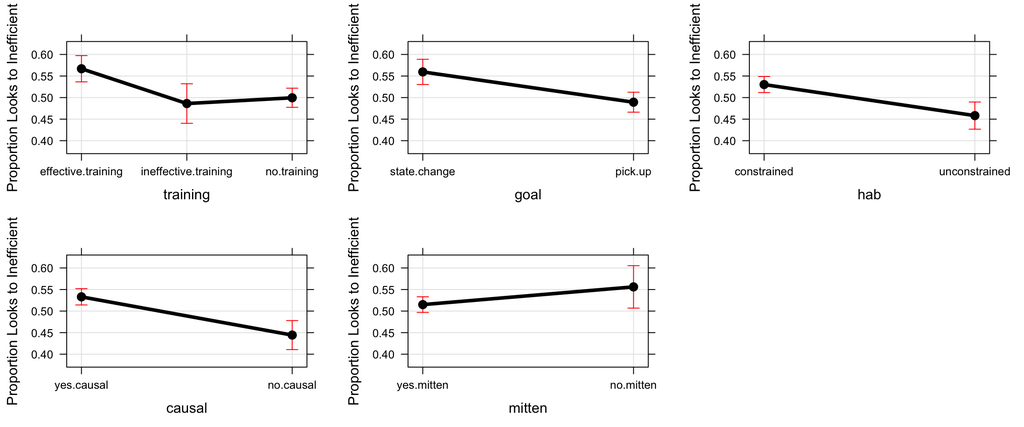

**Figure 3.** Effect plots for model investigating predictors of sensitivity to action efficiency across Experiments 1-5 and Skerry et al. (2013). Each point shows estimates of effects at each level of all categorical predictors. Error bars indicate 95% confidence intervals. See Table 2 for full results.

This analysis confirms that first-person action experience is not the only way to enhance infants’ appreciation of the causal and intentional aspects of action. We found that infants’ expectations were stronger when the observed action was spatiotemporally continuous its effect (i.e., appeared to be causal), [0.027,0.06], ß=0.501, B(SE)=0.044(0.009), p<.001, two-tailed, when infants received effective motor training (sticky mittens), relative to no training [0.027,0.069], ß=0.558, B(SE)=0.049(0.011), p=0.003, two-tailed, when the observed agent’s actions were constrained by a barrier and were efficiently adapted to that barrier, relative to the same actions that were unconstrained by a barrier, [0.021,0.051], ß=0.407, B(SE)=0.036(0.008), p=0.001, two-tailed, and when the agent pursued a state change goal, relative to a pickup goal, [0.02,0.053], ß=0.397, B(SE)=0.035(0.01), p=0.02, two-tailed. We also found that infants’ expectations were marginally *negatively* affected when they received ineffective motor training (non-sticky mittens), relative to no training, [-0.06,-0.005], ß=-0.354, B(SE)=-0.031(0.015), p=0.068, two-tailed, and were unaffected when the actor wore a mitten, relative to no mitten [-0.045,0], ß=-0.232, B(SE)=-0.021(0.012), p=0.14, two-tailed.

# Supplemental Results

## Assessing distribution of looks

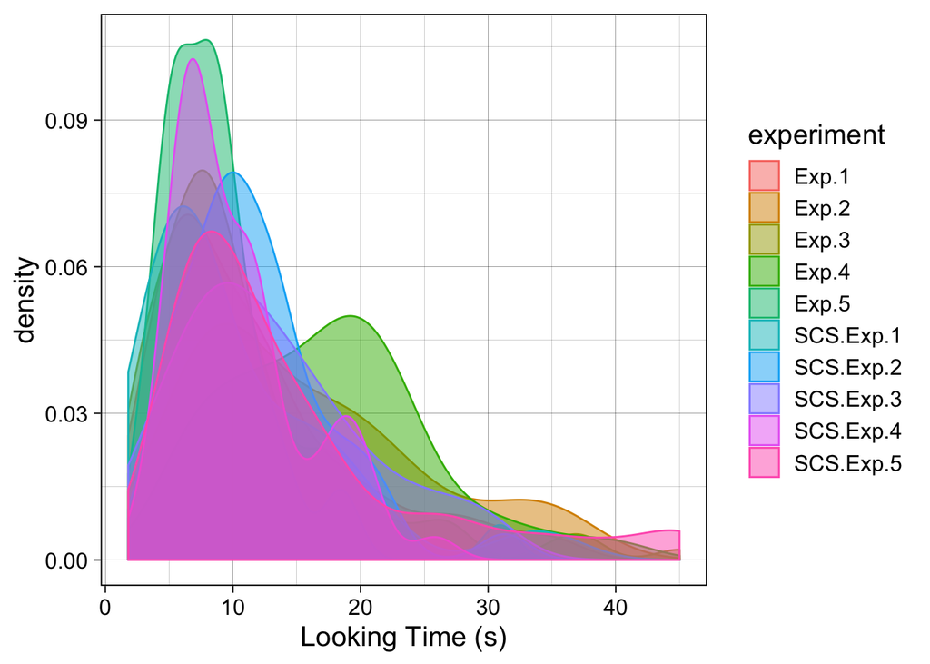

**Figure S1.** Density plot of looking times during test across Experiments 1-5, and Experiments 1-5 from Skerry et al. (2013) (N=264). Maximum-likelihood fitting revealed that the lognormal distribution (log likelihood=-1720.509) provides a better fit to these data than the normal distribution (log likelihood=-1842.196).

## Assessing reliability

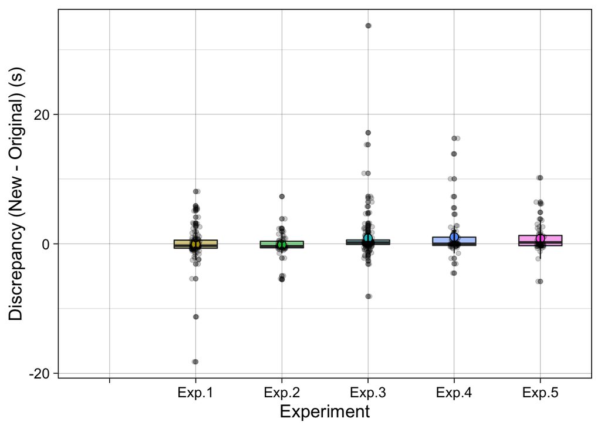

**Figure S2.** Discrepancy between original and new coding of looking times during test trials in seconds.

## Attention during habituation across Exp 1-5

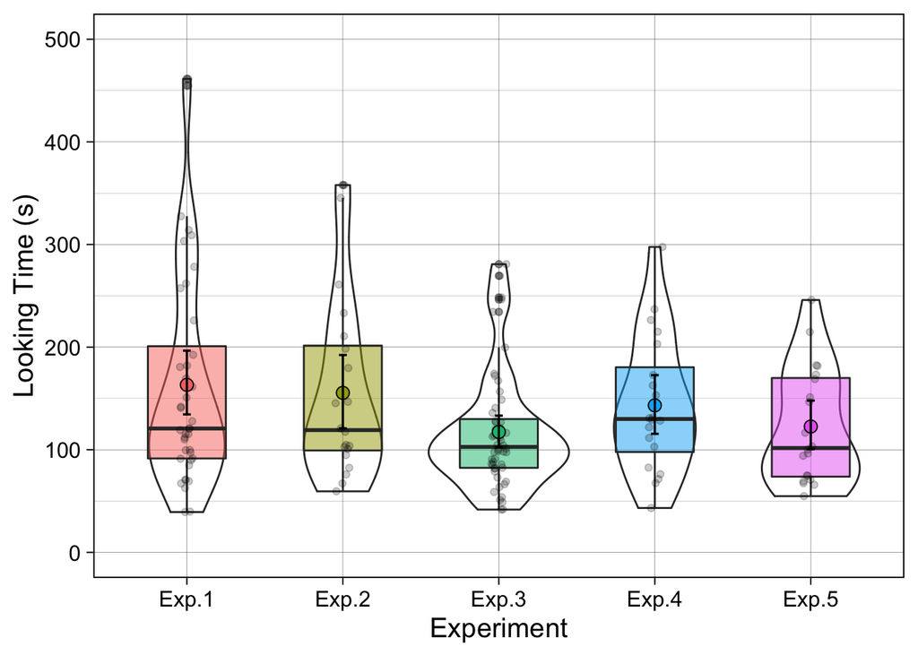

**Figure S3.** Total looking time in seconds during habituation across Experiment 1-5. Error bars around means indicate bootstrapped 95% confidence intervals. Individual points indicate data from a single participant. Horizontal bars within boxes indicate medians, and boxes indicate the middle 2 quartiles of data. Violin plots in indicate distribution of data, area scaled proportionally to the number of observations.

## Exploring effect of test trial order, attention during habituation, age in days, and sex across Exp 1-5

To explore the additional effects of test trial order (inefficient or efficient first), attention during habituation, age in days, and sex on attention during test, we ran one linear model per experiment including an interaction between test event order and test event in Experiments 2, 4, and 5, an interaction between these factors and habituation in Experiment 1, and an interaction between these factors and causal contingency in Experiment 3.

Regression tables for each of these models is below. In general, we find no effect of sex or age, and we consistently find that infants who look longer during habituation also are more attentive during test.

In Experiment 1, we also find that infants randomly assigned to habituate to a rational agent look longer overall at test, [0.022, 0.28], B=0.151, p=0.024, two-tailed, and that infants randomly assigned to view the efficient reach first look longer overall at test, [0.018, 0.276], B=0.147, p=0.027, two-tailed.

### Experiment 1

|  | Standardized Estimate (ß) | Estimate (B) | Standard Error (SE) | df | t | p | 95% CI (Lower) | 95% CI (Upper) |
| --- | --- | --- | --- | --- | --- | --- | --- | --- |
| (Intercept) | 0.012 | 2.579 | 0.941 | 40 | 2.739 | 0.009 | 0.689 | 4.469 |
| hab1 | 0.233 | 0.151 | 0.064 | 40 | 2.350 | 0.024 | 0.022 | 0.280 |
| type1 | 0.050 | 0.032 | 0.033 | 40 | 0.978 | 0.334 | -0.034 | 0.099 |
| first.test1 | 0.227 | 0.147 | 0.064 | 40 | 2.289 | 0.027 | 0.018 | 0.276 |
| scale(total_hab) | 0.463 | 0.003 | 0.001 | 40 | 3.564 | 0.001 | 0.001 | 0.004 |
| sex1 | -0.082 | -0.053 | 0.065 | 40 | -0.815 | 0.420 | -0.185 | 0.078 |
| scale(ageday) | -0.113 | -0.007 | 0.008 | 40 | -0.923 | 0.362 | -0.023 | 0.009 |
| hab1:type1 | 0.149 | 0.096 | 0.033 | 40 | 2.923 | 0.006 | 0.030 | 0.163 |
| hab1:first.test1 | 0.052 | 0.034 | 0.064 | 40 | 0.529 | 0.600 | -0.094 | 0.161 |
| type1:first.test1 | -0.069 | -0.045 | 0.033 | 40 | -1.354 | 0.183 | -0.111 | 0.022 |
| hab1:type1:first.test1 | -0.002 | -0.001 | 0.033 | 40 | -0.032 | 0.974 | -0.067 | 0.065 |

### Experiment 2

|  | Standardized Estimate (ß) | Estimate (B) | Standard Error (SE) | df | t | p | 95% CI (Lower) | 95% CI (Upper) |
| --- | --- | --- | --- | --- | --- | --- | --- | --- |
| (Intercept) | -0.022 | 2.680 | 0.780 | 20 | 3.434 | 0.003 | 1.074 | 4.286 |
| type1 | -0.048 | -0.028 | 0.060 | 20 | -0.464 | 0.648 | -0.148 | 0.093 |
| first.test1 | -0.356 | -0.205 | 0.067 | 20 | -3.045 | 0.006 | -0.339 | -0.072 |
| scale(total_hab) | 0.502 | 0.003 | 0.001 | 20 | 4.146 | 0.000 | 0.002 | 0.005 |
| sex1 | 0.110 | 0.064 | 0.064 | 20 | 0.999 | 0.330 | -0.063 | 0.190 |
| scale(ageday) | -0.085 | -0.006 | 0.007 | 20 | -0.772 | 0.449 | -0.020 | 0.009 |
| type1:first.test1 | -0.036 | -0.021 | 0.060 | 20 | -0.352 | 0.728 | -0.142 | 0.100 |

### Experiment 3

|  | Standardized Estimate (ß) | Estimate (B) | Standard Error (SE) | df | t | p | 95% CI (Lower) | 95% CI (Upper) |
| --- | --- | --- | --- | --- | --- | --- | --- | --- |
| (Intercept) | 0.070 | 2.384 | 0.988 | 52 | 2.414 | 0.019 | 0.412 | 4.356 |
| causal1 | 0.101 | 0.069 | 0.074 | 52 | 0.926 | 0.359 | -0.080 | 0.218 |
| type1 | 0.135 | 0.093 | 0.038 | 52 | 2.444 | 0.018 | 0.017 | 0.169 |
| first.test1 | -0.065 | -0.045 | 0.072 | 52 | -0.618 | 0.540 | -0.189 | 0.100 |
| scale(total_hab) | 0.422 | 0.005 | 0.001 | 52 | 3.660 | 0.001 | 0.002 | 0.008 |
| sex1 | 0.120 | 0.082 | 0.386 | 52 | 0.214 | 0.832 | -0.688 | 0.852 |
| sex2 | 0.001 | 0.001 | 0.215 | 52 | 0.003 | 0.997 | -0.428 | 0.430 |
| scale(ageday) | -0.095 | -0.007 | 0.008 | 52 | -0.841 | 0.404 | -0.024 | 0.010 |
| causal1:type1 | -0.182 | -0.125 | 0.038 | 52 | -3.292 | 0.002 | -0.201 | -0.049 |
| causal1:first.test1 | 0.056 | 0.038 | 0.073 | 52 | 0.521 | 0.605 | -0.108 | 0.185 |
| type1:first.test1 | -0.115 | -0.079 | 0.038 | 52 | -2.074 | 0.043 | -0.155 | -0.003 |
| causal1:type1:first.test1 | 0.004 | 0.003 | 0.038 | 52 | 0.078 | 0.938 | -0.073 | 0.079 |

### Experiment 4

|  | Standardized Estimate (ß) | Estimate (B) | Standard Error (SE) | df | t | p | 95% CI (Lower) | 95% CI (Upper) |
| --- | --- | --- | --- | --- | --- | --- | --- | --- |
| (Intercept) | -0.008 | 1.907 | 1.051 | 20 | 1.815 | 0.085 | -0.255 | 4.070 |
| type1 | 0.020 | 0.010 | 0.040 | 20 | 0.247 | 0.807 | -0.073 | 0.093 |
| first.test1 | -0.190 | -0.093 | 0.077 | 20 | -1.215 | 0.239 | -0.252 | 0.065 |
| scale(total_hab) | 0.650 | 0.005 | 0.001 | 20 | 4.163 | 0.000 | 0.002 | 0.007 |
| sex1 | 0.079 | 0.039 | 0.073 | 20 | 0.533 | 0.600 | -0.111 | 0.188 |
| scale(ageday) | 0.019 | 0.001 | 0.010 | 20 | 0.130 | 0.898 | -0.018 | 0.021 |
| type1:first.test1 | -0.201 | -0.099 | 0.040 | 20 | -2.453 | 0.023 | -0.182 | -0.016 |

### Experiment 5

|  | Standardized Estimate (ß) | Estimate (B) | Standard Error (SE) | df | t | p | 95% CI (Lower) | 95% CI (Upper) |
| --- | --- | --- | --- | --- | --- | --- | --- | --- |
| (Intercept) | -0.024 | 0.901 | 1.221 | 20 | 0.738 | 0.469 | -1.611 | 3.414 |
| type1 | 0.148 | 0.074 | 0.041 | 20 | 1.782 | 0.090 | -0.011 | 0.158 |
| first.test1 | 0.052 | 0.026 | 0.081 | 20 | 0.322 | 0.751 | -0.140 | 0.192 |
| scale(total_hab) | 0.596 | 0.005 | 0.001 | 20 | 3.578 | 0.002 | 0.002 | 0.008 |
| sex1 | 0.118 | 0.059 | 0.080 | 20 | 0.736 | 0.470 | -0.105 | 0.222 |
| scale(ageday) | 0.071 | 0.005 | 0.011 | 20 | 0.429 | 0.673 | -0.017 | 0.027 |
| type1:first.test1 | -0.035 | -0.017 | 0.041 | 20 | -0.419 | 0.680 | -0.102 | 0.068 |

## Reliability

To assess reliability, 50% of test trials from participants across Experiments 1-5 (132 participants, 1011 trials) were randomly selected and coded by additional researchers who were unaware of experimental condition, and test trial order. The intraclass correlation coefficient (ICC) between the original data, and this newly coded data, was 0.968 [0.955, 0.978], 0.963 [0.938, 0.977], 0.936 [0.911, 0.954], 0.969 [0.946, 0.982], 0.969 [0.943, 0.982], for Experiments 1 through 5, respectively.

## Exclusion info

**Table S1.** Tally of infants who participated in Experiments 1-5 but were excluded in our final sample. These exclusion criteria were set prior to the start of data collection, but vary slightly by experiment (e.g. we relaxed our definition of inattentiveness from excluding all data from a participant if they missed a test trial in Experiment 1, to excluding data from just that trial in Experiments 2-5).

[output not shown]